# Report

Betty Wang

2023-03-11

```css
h1{
  color:#cc0066;
  text-align: center;
  font-family: 'Georgia';
  font-style: oblique;
}
h2{
  color: #d580ff;
  font-size: 30px;
  text-align: center;
  font-family: 'Georgia';
}
h3{
  color:#cc0066;
  font-size: 25px;
  text-align: center;
  font-family: 'Georgia';
}
h4{
  color:#cc0066;
  text-align: center;
  font-size: 25px;
  font-family: 'Georgia';
}
p{

  color: #660029;
  font-family: 'Georgia';
}
body
{
    background-image:url('https://cdn.pixabay.com/photo/2023/02/01/21/40/pink-7761356_960_720.png');

}
```

## Project requirements

### GitHub

1. I had create a GitHub account.
2. In my repo I added my personal information and hobbies, as well as the content of our project 1.
3. I know how to upload my HTML pages on to GitHub. My links: -[my repo](https://github.com/Bettyhihi/stats220) -[my website](https://bettyhihi.github.io/stats220/)

### Project folder

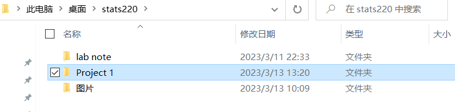

[figure not shown]

### Demonstrates Creativity

-when I created my meme, I used nine imaged that 5 online image and 4 image that create by myself, and use image_append() function to show my meme, and presented in a nine-panel grid. This meme is about, statistics being fun and everyone being able to come and try statistics, and encouraging everyone to work hard.

-When I created my gif, I used seven images and used the image_composite() function to combine two images as the first frame of the gif. My gif is more fun, quiz-style, so that everyone who sees the gif feels engaged, thinks about their favorite food and makes them feel hungry.

## Learning reflection

In this project1 I learnt how to use Rmarkdown to create html pages, how to set headings, use css to change font colours and sizes and page backgrounds, where I found out through self-study that you can use images as backgrounds, not just plain backgrounds. It was very interesting because it looked more beautiful.

I also learnt about the functions in package {magick} to make memes and gifs, and the process y encountered was enjoyable and interesting in solving the bugs.

The things that i am more curious about is exploring more development tools, or functions, to make better looking, more interesting project. For example, the look of the mouse pointer in an html page changes, or play background music while the page is running.